# MAT02014 - Planejamento de Experimentos II Delineamentos fatoriais com dois níveis

Rodrigo Citton P. dos Reis `rodrigocpdosreis@gmail.com` Universidade Federal do Rio Grande do Sul Instituto de Matemática e Estatística Departamento de Estatística

Porto Alegre, 2018

# Delineamentos fatoriais com dois níveis

## Introdução

- Conforme fatores adicionais são acrescentados a um planejamento fatorial, o número de combinações de tratamento no delineamento aumenta exponencialmente.
- O último exemplo que vimos continha quatro fatores e 36 combinações de tratamento.
- Se houvesse cinco fatores em um delineamento, cada um com quatro níveis, o número de combinações de tratamento seria $4 \times 4 \times 4 \times 4 \times 4 = 4^5 = 1024$.
- É fácil perceber que não seriam necessários muitos fatores para tornar o projeto **impraticável**.

## Introdução

- Em outras palavras, ele teria muitas combinações de tratamento para executar em um período de tempo razoável.
- No entanto, é **melhor reduzir o número de níveis** de cada fator e permanecer com o planejamento fatorial **usando todos os fatores** do que reverter para experimentos um a um ou dois de cada vez e perder a eficiência de experimentos fatorial.
- Com experimentos separados, a capacidade de detectar interações de ordem superior e a capacidade de detectar interações entre qualquer par de fatores é perdida.

## Introdução

- Se cinco fatores em um planejamento fatorial fossem estudados com apenas dois níveis cada, o número de combinações de tratamento seria reduzido para $2^5 = 32$.
- Por esta razão, os delineamentos fatoriais com dois níveis para cada fator, ou fatoriais de dois níveis, são populares.
- Uma abreviatura para um fatorial de dois níveis com $k$ fatores é um **delineamento $2^k$**.

## Introdução

- Em fatoriais de dois níveis, se um fator tiver níveis quantitativos, os dois níveis são denotados simbolicamente por $(-)$ e $(+)$.
  - $(-)$ representa o nível **mais baixo** que o pesquisador consideraria.
  - $(+)$ representa o nível **mais alto** que o pesquisador consideraria.
  - As quantidades altas e baixas são geralmente distanciadas o máximo possível, de modo a acentuar o sinal ou a diferença na resposta entre os dois níveis.
- Se um fator tem níveis qualitativos, as designações $(-)$ e $(+)$ são arbitrárias, mas os dois níveis escolhidos normalmente seriam dois que o experimentador acredita que devam resultar na diferença máxima na resposta.

## Efeitos principais e coeficientes de regressão

O modelo para um experimento fatorial com três fatores pode ser escrito como:

$$y_{ijkl} = \mu + \alpha_i +\beta_j + \gamma_k + \alpha\beta_{ij} + \alpha\gamma_{ik} + \beta\gamma_{jk} + \alpha\beta\gamma_{ijk} + \epsilon_{ijkl},$$
em que $\alpha_i$, $\beta_j$, e os demais, são efeitos tais como definimos anteriormente.

## Efeitos principais e coeficientes de regressão

- No caso em que cada fator tem apenas dois níveis representados por $(-)$ e $(+)$, $i$, $j$, $k$ e $l$ podem ser substituídos por um $(-)$ ou $(+)$ e $\alpha_{-} = -\alpha_{+}$.
  - $\alpha_{-} = \bar{y}_{-...} - \bar{y}_{....}$
  - $\alpha_{+} = \bar{y}_{+...} - \bar{y}_{....}$
  - $\bar{y}_{....} = (\bar{y}_{-...} + \bar{y}_{+...})/2$
- Uma igualdade semelhante será verdadeira para todos os efeitos e interações.
- Como os dois efeitos para cada fator são o mesmo valor com sinais diferentes, um modo mais compacto de definir os efeitos principais para um fatorial de dois níveis é $E_A = \bar{y}_{+...} - \bar{y}_{-...}$.

## Efeitos principais e coeficientes de regressão

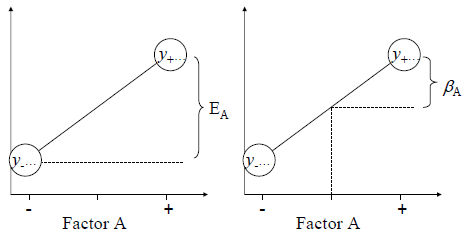

## Efeitos principais e coeficientes de regressão

- A inclinação de regressão $\beta_A$ mostrada no lado direito da figura anterior é a **mudança vertical na resposta média** para uma mudança de **uma unidade** (ou seja, de $0$ a $+1$) no nível de fator em **unidades simbólicas**.
- Portanto, a inclinação, $\beta_A$, é apenas metade do efeito $E_A$, ou a diferença em duas médias dividida por 2.

## Efeitos principais e coeficientes de regressão

- Ordenação (padrão) de Yates.
  - **Para casa:** pesquisar sobre o **algoritmo de Yates**.

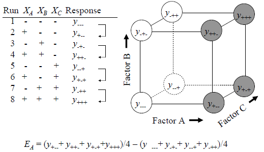

## Efeitos principais e coeficientes de regressão

- Uma das propriedades desejáveis de um plano fatorial $2^k$ é que os efeitos do fator não são obscurecidos por mudanças planejadas em outros fatores.
  - Na lista de experimentos para o projeto $2^k$, mostrada na figura anterior, isso é evidente pelo fato de que, no alto nível de cada fator, há um número igual de altos e baixos níveis de todos os outros fatores.
  - Também no nível baixo de cada fator, há um número igual de níveis altos e baixos de todos os outros fatores.
- Assim, o efeito de um fator, ou diferença na resposta média entre o nível alto e baixo desse fator, representa o efeito desse fator sozinho, porque a influência de todos os outros fatores foi calculada.
  - Matematicamente esta propriedade é chamada ortogonalidade.

## Interações

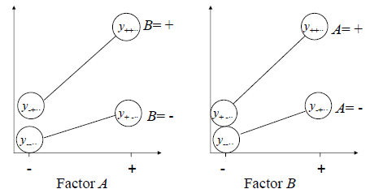

## Interações

- $X_A\cdot X_B$
  - $(-)(-) = +$
  - $(-)(+) = -$
  - $\ldots$

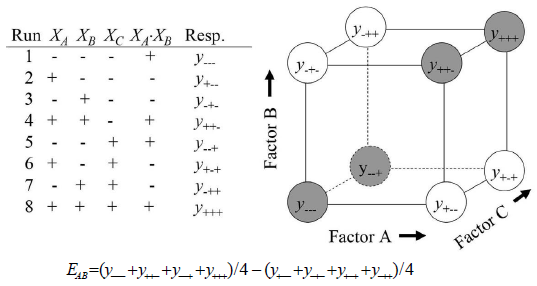

## Interações

### Modelo s regressão

$$\begin{eqnarray*}
y &=& \beta_0 + \beta_AX_A + \beta_BX_B + \beta_CX_C\\
&&\quad + \beta_{AB}X_AX_B + \beta_{AC}X_AX_C + \beta_{BC}X_BX_C\\
&&\quad + \beta_{ABC}X_AX_BX_C + \epsilon.
\end{eqnarray*}$$

## Exemplo de um experimento fatorial $2^3$

- Os estudantes de um laboratório de eletrônica da universidade muitas vezes reclamavam que as medições de voltagem feitas em um circuito construído em sala de aula eram inconsistentes.
- O assistente de ensino do laboratório (TA) decidiu realizar uma experiência para tentar identificar a fonte da variação.
- Os três fatores que ele variou foram:
  - $A$ = a temperatura ambiente onde a medição de voltagem foi feita.
  - $B$ = o tempo de aquecimento do voltímetro.
  - $C$ = o tempo que a energia foi conectada ao circuito antes da medição ser feita. - A resposta foi a tensão medida em milivolts.

## Exemplo de um experimento fatorial $2^3$

- Os dois níveis para o fator $A$ foram:
  - $-$ = 22ºC (temperatura ambiente).
  - $+$ = 32ºC (próximo da temperatura em alguns ambientes industriais).
- Um forno foi usado e o circuito foi autorizado a estabilizar por pelo menos cinco minutos antes das medições.
- As configurações para os fatores $B$ e $C$ foram:
  - $-$ = 30 segundos ou menos
  - $+$ = 5 minutos.
- O mesmo circuito foi medido para cada combinação de fatores de tratamento, de modo que a unidade experimental era nada mais do que a tentativa ou o momento no qual a combinação particular de níveis de fator de tratamento era aplicada para fazer a medição.
- Duas réplicas de cada uma das oito combinações experimentais foram executadas em uma ordem aleatória para ajudar a evitar vieses.

## Exemplo de um experimento fatorial $2^3$

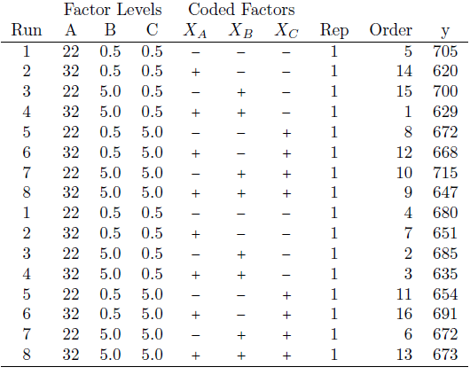

## Exemplo de um experimento fatorial $2^3$

### Níveis dos fatores codificados

$$X_A = \left(\frac{A - 27}{5}\right).$$

- A função `contr.FrF2` do pacote `DoE.base` realiza esta codificação no `R`.

## Exemplo (R)

```r
library(daewr)
data(volt)
head(volt)
```

```
##    A   B   C   y
## 1 22 0.5 0.5 705
## 2 32 0.5 0.5 620
## 3 22   5 0.5 700
## 4 32   5 0.5 629
## 5 22 0.5   5 672
## 6 32 0.5   5 668
```

## Exemplo (R)

```r
library(FrF2)
modv <- lm( y ~ A*B*C, data = volt,
            contrast = list(A = contr.FrF2,
                            B = contr.FrF2,
                            C = contr.FrF2))
summary(modv)
```

```
##
## Call:
## lm.default(formula = y ~ A * B * C, data = volt, contrasts = list(A = contr.FrF2,
##     B = contr.FrF2, C = contr.FrF2))
##
## Residuals:
##    Min     1Q Median     3Q    Max
## -21.50 -11.75   0.00  11.75  21.50
##
## Coefficients:
##             Estimate Std. Error t value Pr(>|t|)
## (Intercept) 668.5625     4.5178 147.985 4.86e-15 ***
## A1          -16.8125     4.5178  -3.721  0.00586 **
## B1            0.9375     4.5178   0.208  0.84079
## C1            5.4375     4.5178   1.204  0.26315
## A1:B1        -6.6875     4.5178  -1.480  0.17707
## A1:C1        12.5625     4.5178   2.781  0.02390 *
## B1:C1         1.8125     4.5178   0.401  0.69878
## A1:B1:C1     -5.8125     4.5178  -1.287  0.23422
## ---
## Signif. codes:  0 '***' 0.001 '**' 0.01 '*' 0.05 '.' 0.1 ' ' 1
##
## Residual standard error: 18.07 on 8 degrees of freedom
## Multiple R-squared:  0.772,  Adjusted R-squared:  0.5724
## F-statistic: 3.869 on 7 and 8 DF,  p-value: 0.0385
```

## Exemplo

- O efeito do fator $A$ é o dobro do coeficiente de regressão mostrado na saída do `R`.
  - $E_A = 2 \times \hat{\beta}_A = 2(−16.8125) = −33.625$.
- Isso significa que, em média, quando a temperatura ambiente é aumentada de 22ºC para 32ºC, a medição de tensão diminuirá em 33,6 milivolts.
- **Pergunta:** esta conclusão é válida?

## Exemplo (R)

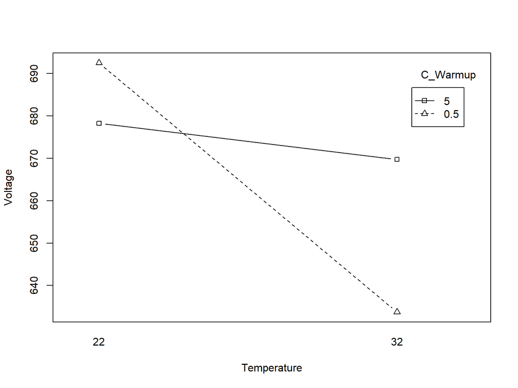

```r
C_Warmup <- volt$C
with(volt, (interaction.plot(A, C_Warmup, y, type = "b",
                             pch = c(24,22), leg.bty = "o",
                             xlab = "Temperature",ylab = "Voltage")))
```

## Exemplo (R)

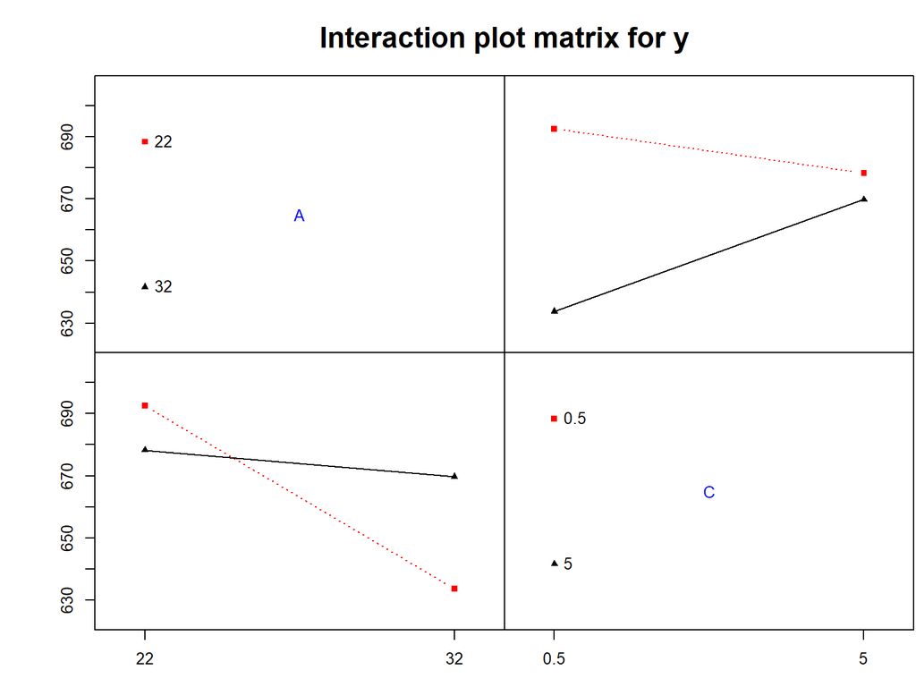

```r
IAPlot(modv, select = c(1,3))
```

## Exemplo (R)

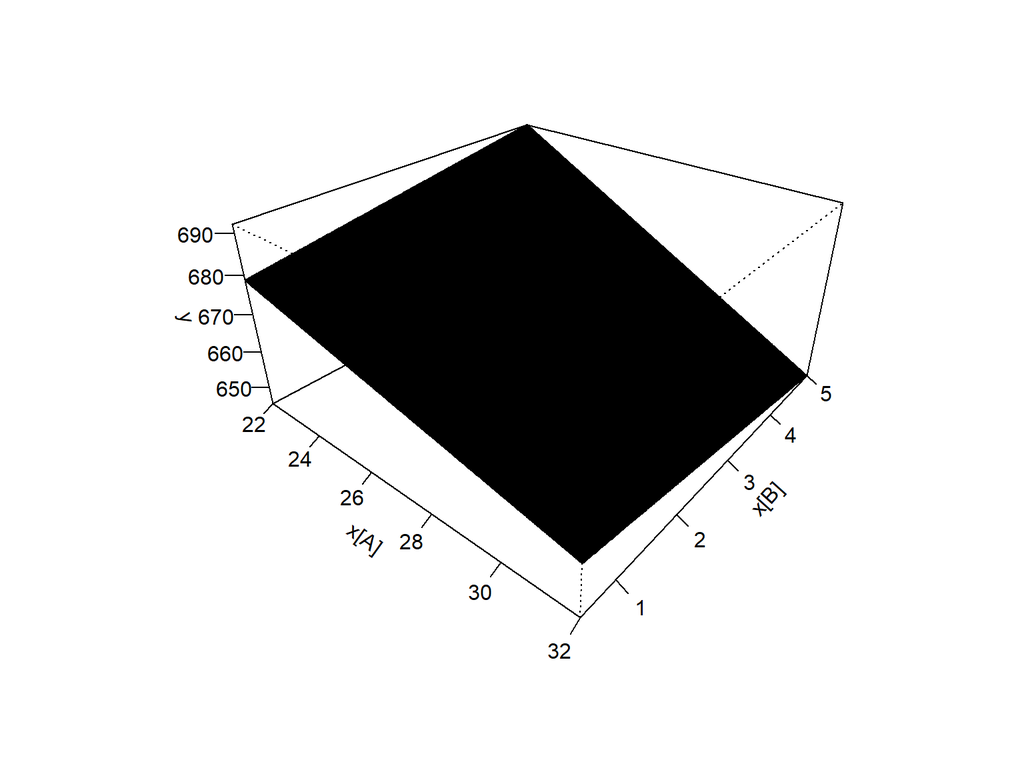

## Exemplo (R)

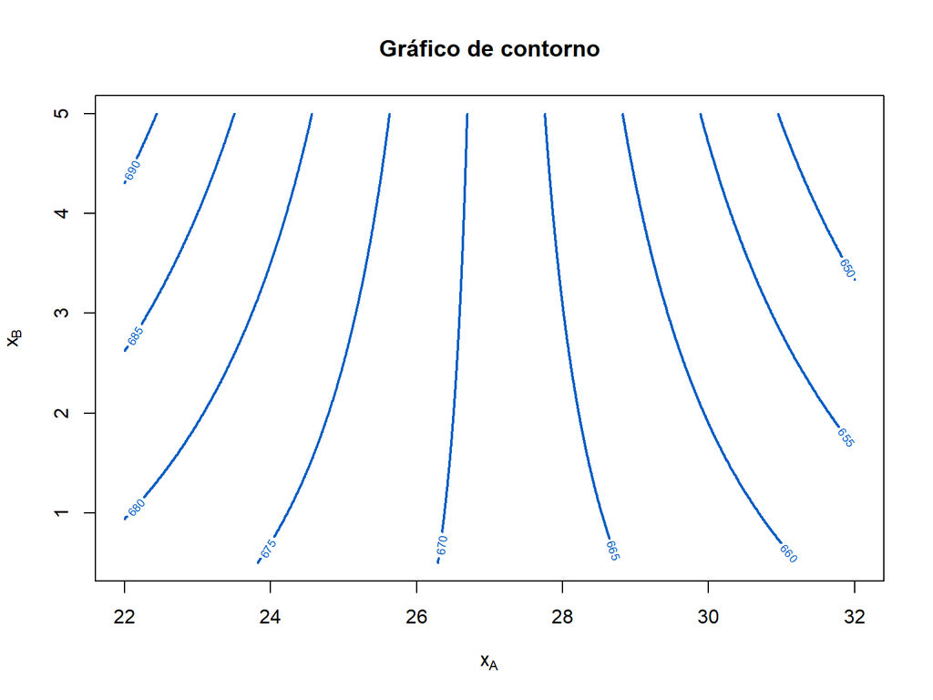

# Análise com uma replicação por célula

## Análise com uma replicação por célula

- Delineamentos fatoriais com uma replicação por célula são usualmente chamados de **delineamentos sem replicação**.
- Quando há poder adequado para detectar efeitos com $n = 1$ replicação por célula, ou combinação de tratamento, não há necessidade de dobrar o trabalho experimental replicando cada experimento.
- No entanto, em um delineamento fatorial não replicado, surge um problema já discutido.
  - **Pergunta:** qual é este problema?

## Análise com uma replicação por célula

- Haverá zero graus de liberdade para calcular $SS_E$ e, portanto, nenhum teste $F$ para os efeitos.
- No entanto, quando há múltiplos fatores em um fatorial de dois níveis, existem **ferramentas gráficas simples** que permitem a detecção dos efeitos significativos.
- Como nem todos os efeitos principais e interações em um experimento de $2^k$ devem ser significativos, os níveis de fatores insignificantes e combinações de níveis definidos pelas interações insignificantes são **equivalentes** a ter replicações no delineamento.
- Ferramentas gráficas permitem que os efeitos significativos (ou coeficientes de regressão equivalentes) sejam reconhecidos.

## Exemplo

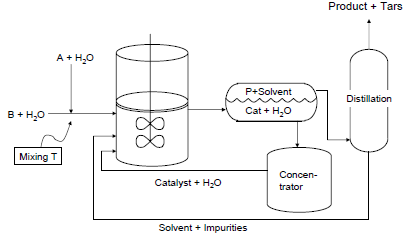

## Exemplo

- A figura anterior é um diagrama de um **processo químico contínuo**.
1. Neste processo, correntes contínuas de dois reagentes, A e B, são combinadas em uma junção chamada de mistura-T, onde elas começam a reagir.
2. A mistura então flui para um reator e é combinada com solvente e um catalisador e a reação é completada.
3. O resultado da reação flui para um tanque separador, onde o produto final flutua para o topo em uma fase de solvente, enquanto o catalisador e a água vão para o fundo do tanque.
4. O catalisador é concentrado e enviado de volta ao reator, enquanto o produto, subprodutos e solvente são levados para uma coluna de destilação onde o produto é removido e o solvente é reciclado para o reator.

## Exemplo

- Um dos problemas vivenciados nesse processo foi a produção de **subprodutos** (resíduos).
- Com o tempo, esses resíduos entupiriam o reator e forçariam o desligamento do processo para limpeza.
- Também exigiu uma etapa adicional do processo para purificar o produto final.
- Os engenheiros decidiram conduzir experimentos para ver se poderiam **aumentar a conversão percentual**, o que **reduziria a quantidade de subprodutos**.

## Exemplo

- Os fatores que eles achavam que poderiam afetar a conversão percentual são:
  - $A$: Excesso de Reagente A (sobre quantidade molar)
  - $B$: Concentração do Catalisador
  - $C$: Pressão no Reator
  - $D$: Temperatura da Mistura Revestida-T

## Exemplo

- **Dois níveis** de cada fator foram escolhidos.
  - Estes foram espalhados tão largamente quanto os engenheiros julgaram viável, a fim de maximizar a chance de detectar os efeitos dos fatores com apenas dois níveis.
- Durante a experimentação, os níveis dos fatores seriam alterados após um intervalo de tempo fixo.
- A unidade experimental para isto seria os reagentes particulares, o catalisador e o solvente que entrava na zona de reação durante uma determinada rodada.
- A resposta $Y$ seria a **conversão percentual** calculada a partir do produto produzido durante uma rodada.
- Foi estabelecido que um delineamento sem replicação seria suficiente para detectar os efeitos.

## Exemplo

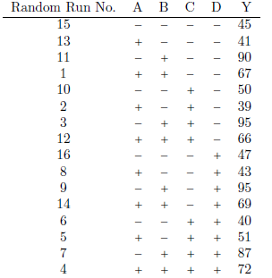

## Exemplo (R)

```r
library(daewr)
data(chem)
head(chem)
```

```
##    A  B  C  D  y
## 1 -1 -1 -1 -1 45
## 2  1 -1 -1 -1 41
## 3 -1  1 -1 -1 90
## 4  1  1 -1 -1 67
## 5 -1 -1  1 -1 50
## 6  1 -1  1 -1 39
```

## Exemplo (R)

```r
modf <- lm( y ~ A*B*C*D, data = chem)
anova(modf)
```

```
## Analysis of Variance Table
##
## Response: y
##           Df Sum Sq Mean Sq F value Pr(>F)
## A          1  637.6   637.6
## B          1 5076.6  5076.6
## C          1    0.6     0.6
## D          1    7.6     7.6
## A:B        1  451.6   451.6
## A:C        1   10.6    10.6
## B:C        1    1.6     1.6
## A:D        1   68.1    68.1
## B:D        1    0.1     0.1
## C:D        1    7.6     7.6
## A:B:C      1    0.6     0.6
## A:B:D      1    7.6     7.6
## A:C:D      1   95.1    95.1
## B:C:D      1    3.1     3.1
## A:B:C:D    1    1.6     1.6
## Residuals  0    0.0
```

## Exemplo (R)

```r
summary(modf)
```

```
##
## Call:
## lm.default(formula = y ~ A * B * C * D, data = chem)
##
## Residuals:
## ALL 16 residuals are 0: no residual degrees of freedom!
##
## Coefficients:
##             Estimate Std. Error t value Pr(>|t|)
## (Intercept)  62.3125         NA      NA       NA
## A            -6.3125         NA      NA       NA
## B            17.8125         NA      NA       NA
## C             0.1875         NA      NA       NA
## D             0.6875         NA      NA       NA
## A:B          -5.3125         NA      NA       NA
## A:C           0.8125         NA      NA       NA
## B:C          -0.3125         NA      NA       NA
## A:D           2.0625         NA      NA       NA
## B:D          -0.0625         NA      NA       NA
## C:D          -0.6875         NA      NA       NA
## A:B:C        -0.1875         NA      NA       NA
## A:B:D        -0.6875         NA      NA       NA
## A:C:D         2.4375         NA      NA       NA
## B:C:D        -0.4375         NA      NA       NA
## A:B:C:D      -0.3125         NA      NA       NA
##
## Residual standard error: NaN on 0 degrees of freedom
## Multiple R-squared:      1,  Adjusted R-squared:    NaN
## F-statistic:   NaN on 15 and 0 DF,  p-value: NA
```

## Exemplo

- Os coeficientes de regressão para os efeitos principais $A$ e $B$, juntamente com a interação $AB$, são os maiores efeitos, mas um gráfico deve ser usado para determinar quais são significativos.
- Os efeitos em um delineamento fatorial de dois níveis são a diferença de duas médias.
- Se as mudanças nos níveis dos fatores não causarem uma mudança na resposta, o efeito será apenas a diferença nas médias dos dados aleatórios (devido a flutuações aleatórias no erro experimental).

## Exemplo

- Se nenhum dos fatores ou interações causar mudanças na resposta, todo o **conjunto de efeitos**, ou **coeficientes de regressão**, devem aparecer como uma amostra da distribuição normal com média zero devido ao Teorema Central do Limite.
- Portanto, se fizermos um gráfico de probabilidade normal dos efeitos, os **efeitos insignificantes** deverão estar ao longo de uma linha reta e quaisquer **efeitos significativos** ou interações deverão aparecer como valores discrepantes no gráfico.

## Exemplo (R)

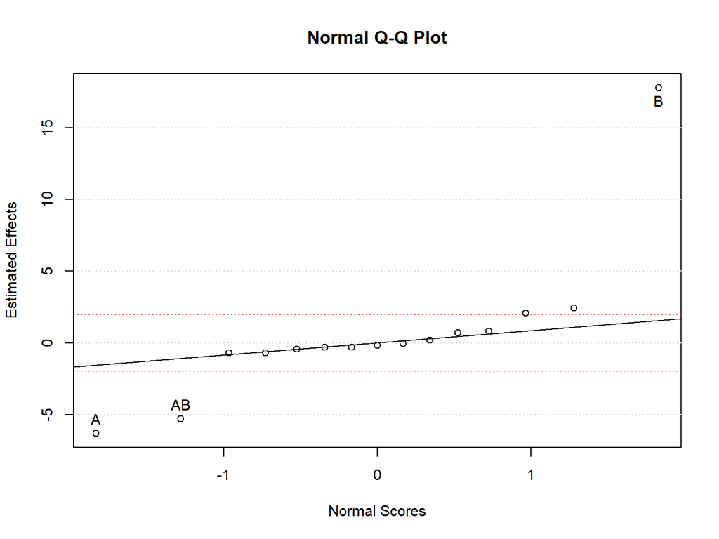

```r
fullnormal(coef(modf)[-1], alpha = 0.025)
abline(h =  seq(-5, 15, by = 5), col = "lightgrey", lty = 3)
abline(h =  1.96 * c(-1, 1), col = "red", lty = 3)
```

## Exemplo (R)

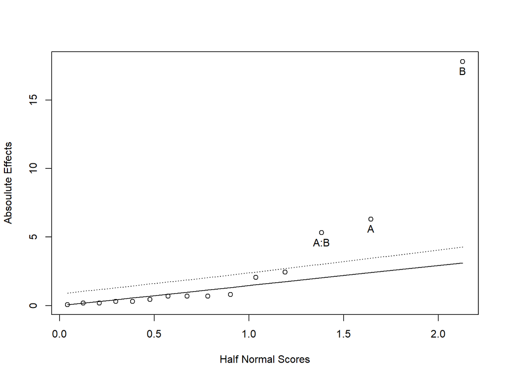

```r
LGB( coef(modf)[-1], rpt = FALSE)
```

## Exemplo (R)

```r
LGB( coef(modf)[-1], rpt = TRUE, plt = FALSE)
```

```
## Effect Report
##
## Label     Half Effect    Sig(.05)
## A         -6.3125        yes
## B         17.8125        yes
## C          0.1875        no
## D          0.6875        no
## A:B       -5.3125        yes
## A:C        0.8125        no
## B:C       -0.3125        no
## A:D        2.0625        no
## B:D       -0.0625        no
## C:D       -0.6875        no
## A:B:C     -0.1875        no
## A:B:D     -0.6875        no
## A:C:D      2.4375        no
## B:C:D     -0.4375        no
## A:B:C:D   -0.3125        no
##
## Lawson, Grimshaw & Burt Rn Statistic =  3.006953
## 95th percentile of Rn =  1.201
```

## Exemplo

- **Pergunta:** o que podemos concluir?

## Exemplo (R)

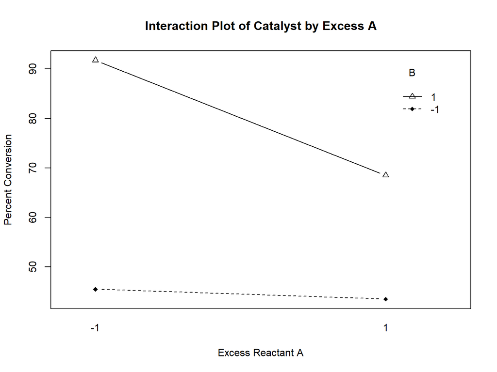

```r
with(chem,
     (interaction.plot( A, B, y, type = "b",
                        pch = c(18,24),
                        main = "Interaction Plot of Catalyst by Excess A",
                        xlab = "Excess Reactant A",
                        ylab = "Percent Conversion")))
```

## Exemplo (R)

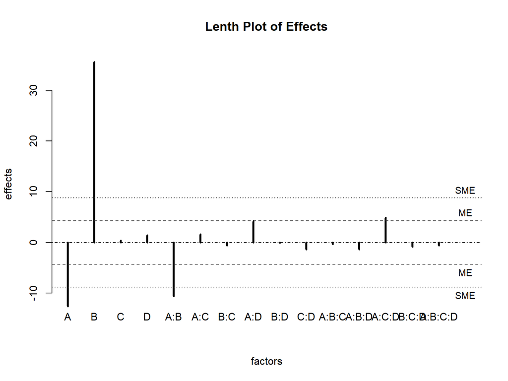

```
##    alpha      PSE       ME      SME
## 0.050000 1.687500 4.337857 8.806474
```

```r
library(BsMD)
LenthPlot(modf, main = "Lenth Plot of Effects")
```

## Exemplo (R)

```r
X <- model.matrix(modf)[ , 2:16]
y <- chem$y
Chem.BsProb <- BsProb( X = X, y = y,
                       blk = 0, mFac = 15,
                       mInt = 1, p = 0.2,
                       g = 2.49, ng = 1,
                       nMod = 10)
summary(Chem.BsProb)
```

```
##
##  Calculations:
##     nRun     nFac     nBlk     mFac     mInt        p        g   totMod
##    16.00    15.00     0.00    15.00     1.00     0.20     2.49 32768.00
##
##  Factor probabilities:
##     Factor Code  Prob
## 1     none none 0.000
## 2        A   x1 0.995
## 3        B   x2 1.000
## 4        C   x3 0.025
## 5        D   x4 0.035
## 6      A:B   x5 0.987
## 7      A:C   x6 0.040
## 8      B:C   x7 0.026
## 9      A:D   x8 0.365
## 10     B:D   x9 0.024
## 11     C:D  x10 0.035
## 12   A:B:C  x11 0.025
## 13   A:B:D  x12 0.035
## 14   A:C:D  x13 0.533
## 15   B:C:D  x14 0.028
## 16 A:B:C:D  x15 0.026
##
##  Model probabilities:
##     Prob  Sigma2 NumFac Factors
## M1  0.279 17.69  3      1,2,5
## M2  0.199  6.92  5      1,2,5,8,13
## M3  0.187 11.41  4      1,2,5,13
## M4  0.063 13.19  4      1,2,5,8
## M5  0.011  6.22  6      1,2,5,6,8,13
## M6  0.009 16.99  4      1,2,5,6
## M7  0.009  6.42  6      1,2,5,8,12,13
## M8  0.009  6.42  6      1,2,5,8,10,13
## M9  0.009  6.42  6      1,2,4,5,8,13
## M10 0.009 17.19  4      1,2,5,12
```

## Exemplo (R)

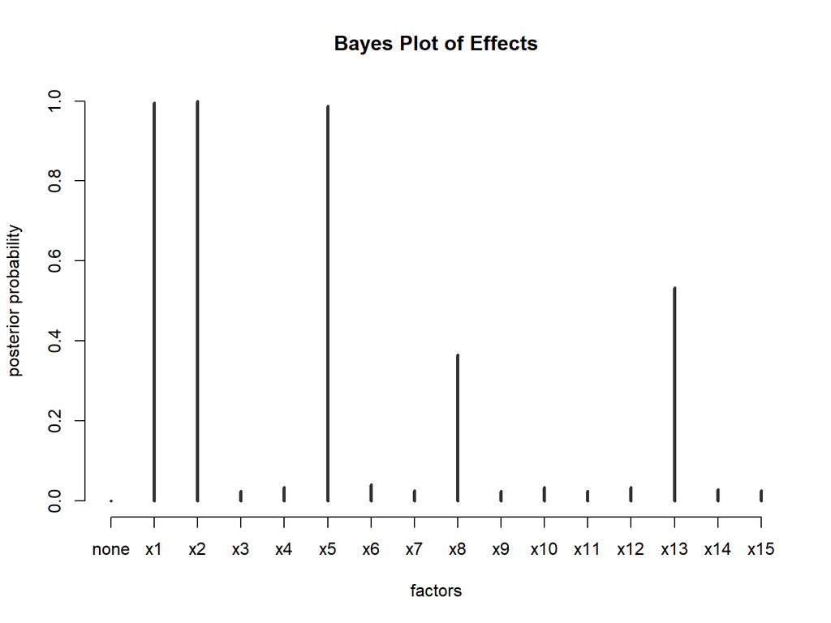

```r
plot( Chem.BsProb, main = "Bayes Plot of Effects" )
```

## Veja também

- **R Commander:** jlawson.byu.edu
- Por que não utilizamos o teste de Tukey com 1 grau de liberdade para testar a suposição de não aditividade (ausência de interação)?

[figure not shown]